# Lab04: Drzewa decyzyjne i lasy losowe

2022-06-14

## Medical Cost Personal Datasets

### Load dataset

```r
insurance <- read.csv(file = 'insurance.csv')
attach(insurance)
```

Konwersja danych

```r
insurance$sex <- as.factor(insurance$sex)
insurance$smoker <- as.factor(insurance$smoker)
insurance$region <- as.factor(insurance$region)
insurance$age <- as.numeric(insurance$age)
insurance$children <- as.numeric(insurance$children)
```

### Regression tree

```r
charges_tree <- tree(charges ~., data = insurance)
summary(charges_tree)
```

```
##
## Regression tree:
## tree(formula = charges ~ ., data = insurance)
## Variables actually used in tree construction:
## [1] "smoker" "age"    "bmi"
## Number of terminal nodes:  4
## Residual mean deviance:  25370000 = 3.385e+10 / 1334
## Distribution of residuals:
##    Min. 1st Qu.  Median    Mean 3rd Qu.    Max.
##   -9144   -3065   -1057       0    1073   24610
```

*Deviance* oznacza w tym przypadku RSS, czyli resztową sumę kwadratów. Przedstawienie drzewa

```r
charges_tree
```

```
## node), split, n, deviance, yval
##       * denotes terminal node
##
## 1) root 1338 1.961e+11 13270
##   2) smoker: no 1064 3.819e+10  8434
##     4) age < 42.5 596 1.320e+10  5399 *
##     5) age > 42.5 468 1.251e+10 12300 *
##   3) smoker: yes 274 3.637e+10 32050
##     6) bmi < 30.01 130 3.287e+09 21370 *
##     7) bmi > 30.01 144 4.859e+09 41690 *
```

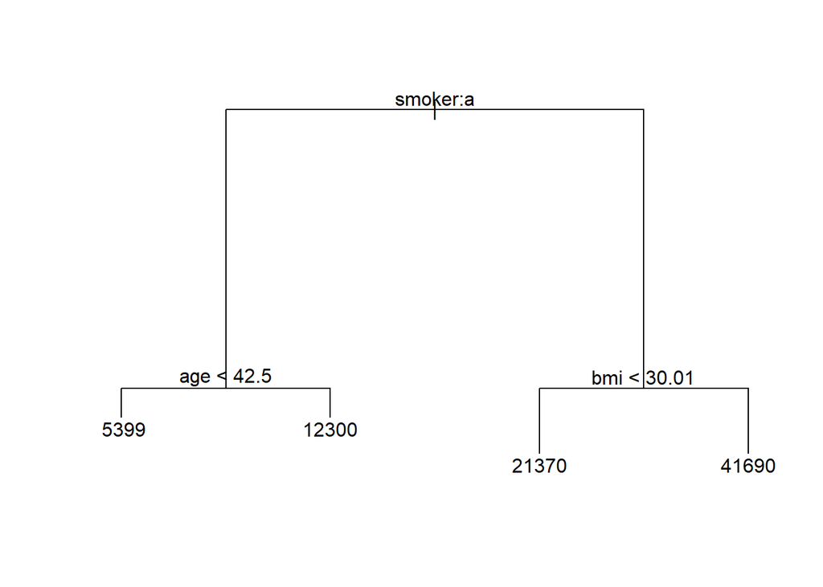

```r
plot(charges_tree)
text(charges_tree)
```

Drzewo decyzyjne dla zbioru treningowego

```r
set.seed(1)
n <- nrow(insurance)
train <- sample(n, n / 2)
test <- -train
charges_tree <- tree(charges ~., data = insurance, subset = train)
charges_pred <- predict(charges_tree, newdata = insurance[test,])
mean((charges_pred - insurance$charges[test])^2)
```

```
## [1] 27723712
```

Wyznaczamy optymalne poddrzewo metodą przycinania sterowanego złożonością

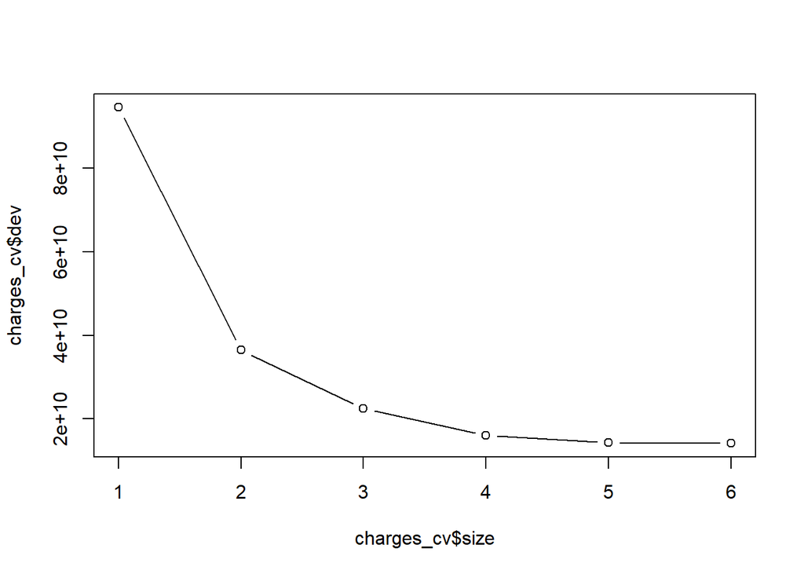

```r
charges_cv <- cv.tree(charges_tree)
plot(charges_cv$size, charges_cv$dev, type = "b")
```

Wybieramy rozmiar drzewa dla najmniejszego błędu

```r
size_opt <- charges_cv$size[which.min(charges_cv$dev)]
size_opt
```

```
## [1] 6
```

Przycinamy drzewo do zadanego poziomu

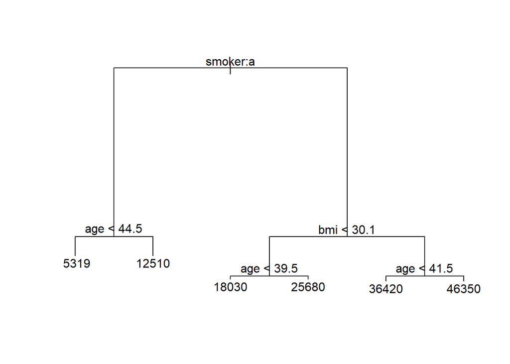

```r
charges_pruned <- prune.tree(charges_tree, best = size_opt)
plot(charges_pruned)
text(charges_pruned)
```

## Classification tree

```r
smoker_tree <- tree(smoker ~., data = insurance)
summary(smoker_tree)
```

```
##
## Classification tree:
## tree(formula = smoker ~ ., data = insurance)
## Variables actually used in tree construction:
## [1] "charges" "bmi"
## Number of terminal nodes:  6
## Residual mean deviance:  0.166 = 221.1 / 1332
## Misclassification error rate: 0.03438 = 46 / 1338
```

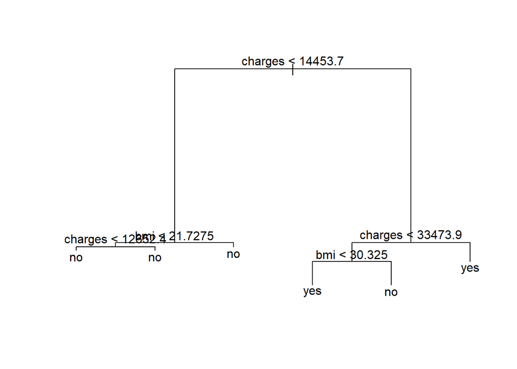

```r
plot(smoker_tree)
text(smoker_tree, pretty = 0)
```

```r
smoker_tree
```

```
## node), split, n, deviance, yval, (yprob)
##       * denotes terminal node
##
##  1) root 1338 1357.00 no ( 0.795217 0.204783 )
##    2) charges < 14453.7 971   51.92 no ( 0.995881 0.004119 )
##      4) bmi < 21.7275 68   30.43 no ( 0.941176 0.058824 )
##        8) charges < 12652.4 59    0.00 no ( 1.000000 0.000000 ) *
##        9) charges > 12652.4 9   12.37 no ( 0.555556 0.444444 ) *
##      5) bmi > 21.7275 903    0.00 no ( 1.000000 0.000000 ) *
##    3) charges > 14453.7 367  423.90 yes ( 0.264305 0.735695 )
##      6) charges < 33473.9 218  298.10 yes ( 0.431193 0.568807 )
##       12) bmi < 30.325 163  179.40 yes ( 0.239264 0.760736 ) *
##       13) bmi > 30.325 55    0.00 no ( 1.000000 0.000000 ) *
##      7) charges > 33473.9 149   29.37 yes ( 0.020134 0.979866 ) *
```

Tworzymy drzewo dla zbioru uczącego i sprawdzamy skuteczność.

```r
set.seed(1)
n <- nrow(insurance)
train <- sample(n, n / 2)
test <- -train
smoker_tree <- tree(smoker ~., data = insurance, subset = train)
tree_class <- predict(smoker_tree, newdata = insurance[test,], type = "class")
table(tree_class, insurance$smoker[test])
```

```
##
## tree_class  no yes
##        no  505   2
##        yes  27 135
```

```r
mean(tree_class != insurance$smoker[test])
```

```
## [1] 0.04334828
```

Pełne drzewo dla zbioru uczącego

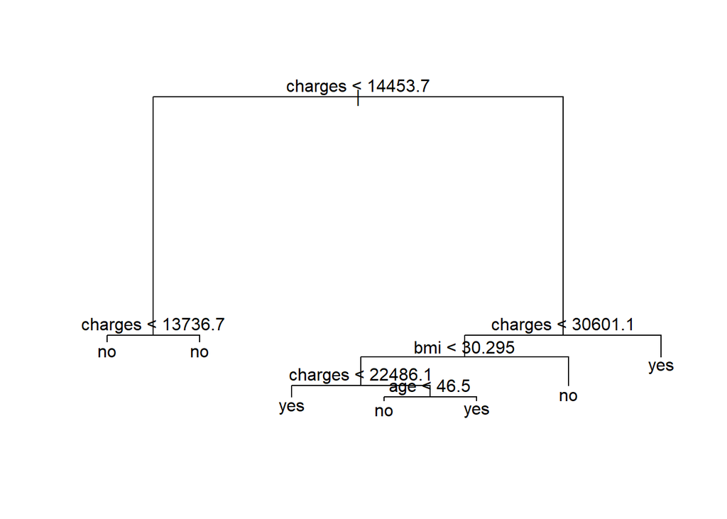

```r
plot(smoker_tree)
text(smoker_tree, pretty = 0)
```

Do znalezienia optymalnego poddrzewa stosujemy przycinanie stosowane złożonością. Przy pomocy CV konstruujemy ciąg poddrzew wyznaczony przez malejącą złożoność.

```r
set.seed(1)
smoker_cv <- cv.tree(smoker_tree, FUN = prune.misclass)
smoker_cv
```

```
## $size
## [1] 7 6 4 2 1
##
## $dev
## [1]  24  24  20  42 137
##
## $k
## [1] -Inf  0.0  3.0 11.5 96.0
##
## $method
## [1] "misclass"
##
## attr(,"class")
## [1] "prune"         "tree.sequence"
```

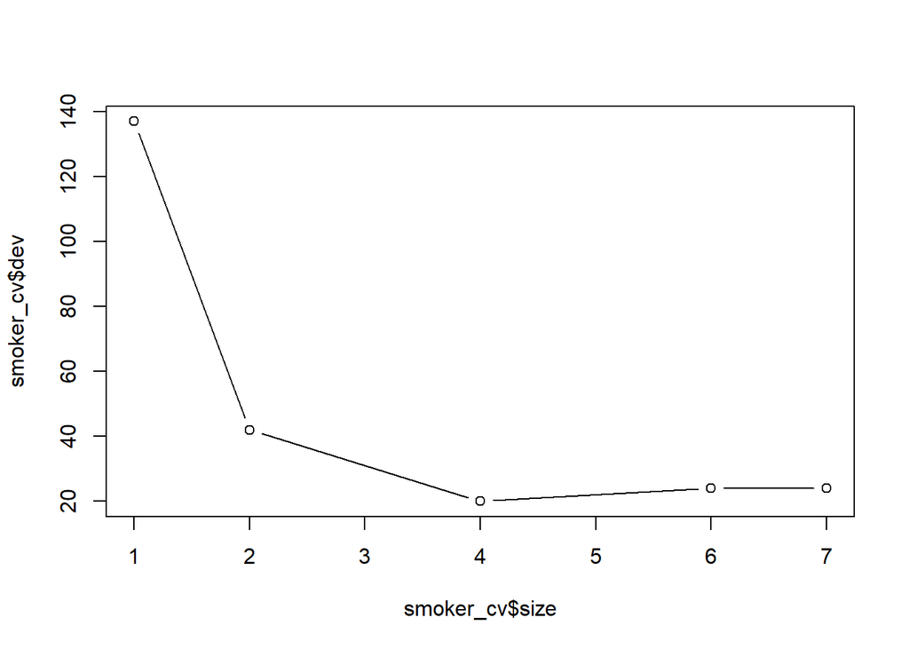

```r
plot(smoker_cv$size, smoker_cv$dev, type = "b")
```

Składowa `smoker_cv$dev` zawiera liczbę błędów CV. Przycinamy drzewo do poddrzewa z najmniejszym poziomem błędów CV.

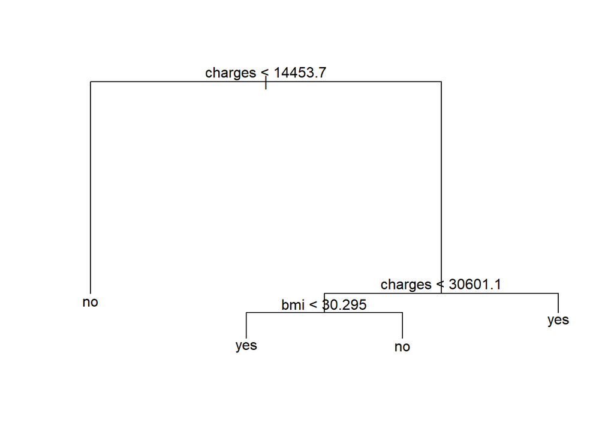

```r
size_opt <- smoker_cv$size[which.min(smoker_cv$dev)]
smoker_pruned <- prune.misclass(smoker_tree, best = size_opt)
plot(smoker_pruned)
text(smoker_pruned, pretty = 0)
```

Testowy poziom błędów dla optymalnego poddrzewa.

```r
pruned_class <- predict(smoker_pruned, newdata = insurance[test,],
                        type = "class")
table(pruned_class, insurance$smoker[test])
```

```
##
## pruned_class  no yes
##          no  504   2
##          yes  28 135
```

```r
mean(pruned_class != insurance$smoker[test])
```

```
## [1] 0.04484305
```

### Bagging (regresja)

```r
charges_bag <- randomForest(charges ~ ., data = insurance, mtry = 6, importance = TRUE)
charges_bag
```

```
##
## Call:
##  randomForest(formula = charges ~ ., data = insurance, mtry = 6,      importance = TRUE)
##                Type of random forest: regression
##                      Number of trees: 500
## No. of variables tried at each split: 6
##
##           Mean of squared residuals: 22618685
##                     % Var explained: 84.57
```

Wykres błędu OOB względem liczby drzew

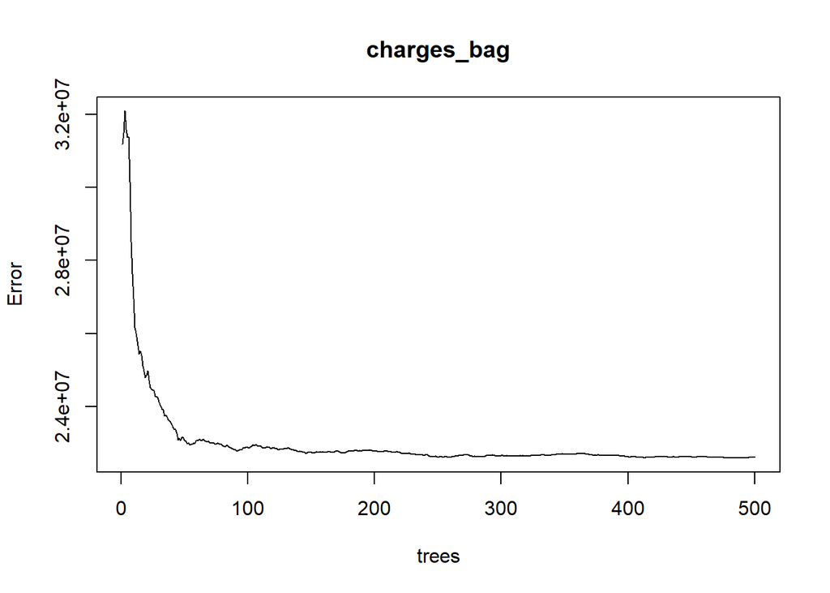

```r
plot(charges_bag, type = "l")
```

Wyznaczenie ważności predyktorów

```r
importance(charges_bag)
```

```
##             %IncMSE IncNodePurity
## age      124.771042   24490165176
## sex       -2.717201     745233162
## bmi      129.664823   39027208665
## children  25.612782    3233740745
## smoker   243.110473  121459333298
## region    13.163882    2678302894
```

Wykres objaśniający ważność predyktoróW

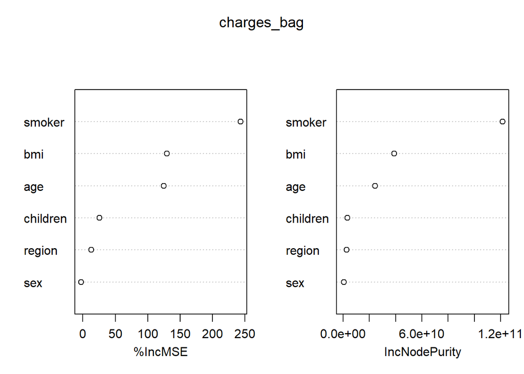

```r
varImpPlot(charges_bag)
```

Oszacowanie błędu testowego dla poprzednio wyznaczonego zbioru walidacyjnego.

```r
set.seed(2)
charges_bag <- randomForest(charges ~ ., data = insurance, subset = train, mtry = 6,
                         importance = TRUE)
charges_pred_bag <- predict(charges_bag, newdata = insurance[test,])
mean((charges_pred_bag - insurance$charges[test])^2)
```

```
## [1] 26256354
```

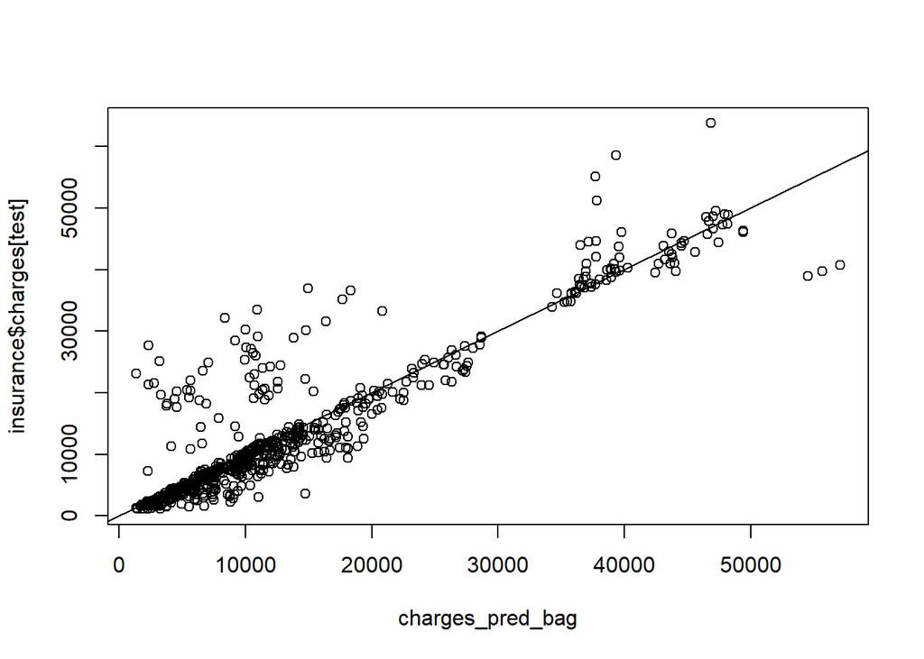

```r
plot(charges_pred_bag , insurance$charges[test])
abline (0,1)
```

To samo co wyżej dla mniejszej liczby hodowanych drzew

```r
set.seed(2)
charges_bag_s <- randomForest(charges ~ ., data = insurance, subset = train, mtry = 6, importance = TRUE, ntree = 25)
charges_pred_bag_s <- predict(charges_bag_s, newdata = insurance[test,])
mean((charges_pred_bag_s - insurance$charges[test])^2)
```

```
## [1] 26326002
```

### Bagging (klasyfikacja)

```r
smoker_bag <- randomForest(smoker ~ ., data = insurance, mtry = 6, importance = TRUE)
smoker_bag
```

```
##
## Call:
##  randomForest(formula = smoker ~ ., data = insurance, mtry = 6,      importance = TRUE)
##                Type of random forest: classification
##                      Number of trees: 500
## No. of variables tried at each split: 6
##
##         OOB estimate of  error rate: 2.77%
## Confusion matrix:
##       no yes class.error
## no  1037  27  0.02537594
## yes   10 264  0.03649635
```

Wykres błędu OOB względem liczby drzew

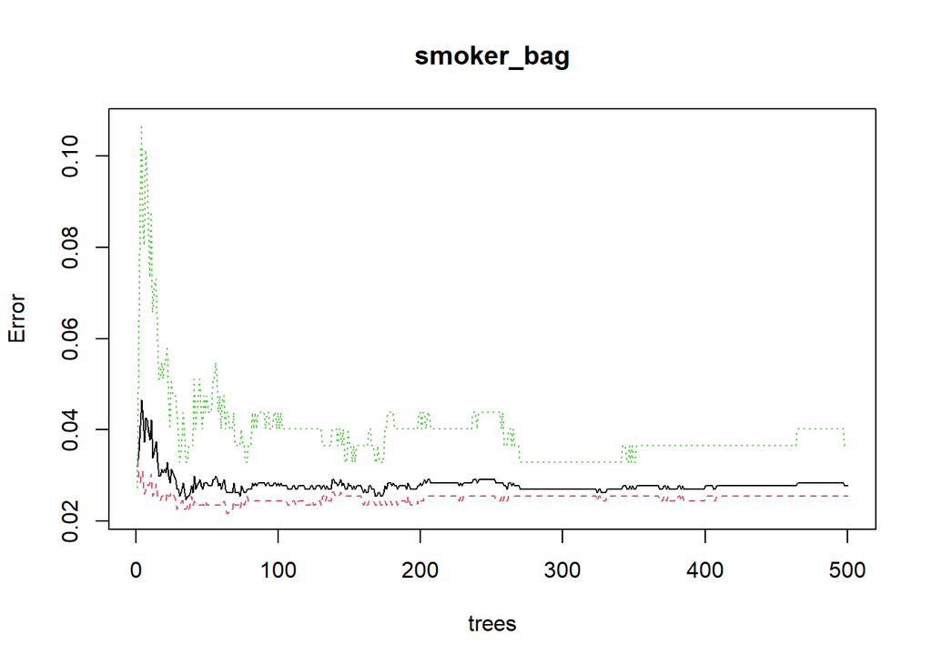

```r
plot(smoker_bag, type = "l")
```

Wyznaczenie ważności predyktorów

```r
importance(smoker_bag)
```

```
##                   no        yes MeanDecreaseAccuracy MeanDecreaseGini
## age        6.1091797  45.806495            42.447902       23.0326042
## sex       -0.3731521  -1.746490            -1.835760        0.5243831
## bmi        9.4105351  82.328003            74.948942       60.8227587
## children  -3.5658419  11.035690             8.265264        4.4578467
## region    -2.3360449  -3.126967            -3.920652        2.3568571
## charges  147.0434519 337.625840           251.341093      343.2920943
```

Obrazek ważności predyktorów

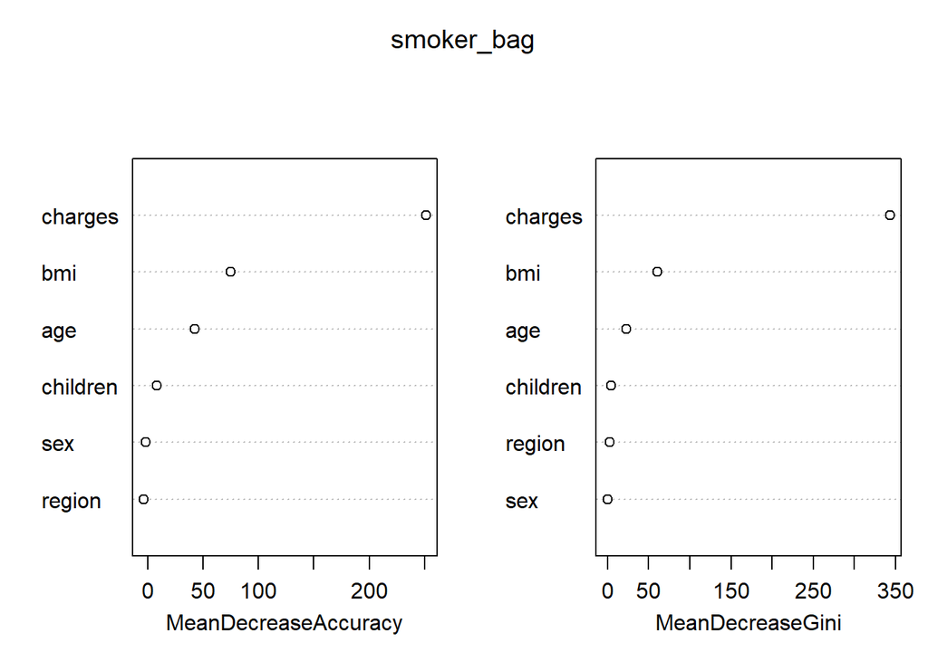

```r
varImpPlot(smoker_bag)
```

Oszacowanie błędu testowego dla poprzednio wyznaczonego zbioru walidacyjnego.

```r
set.seed(2)
smoker_bag <- randomForest(smoker ~ ., data = insurance, subset = train, mtry = 6, importance = TRUE)
smoker_pred_bag <- predict(smoker_bag, newdata = insurance[test,], type="class")
importance(smoker_bag)
```

```
##                   no         yes MeanDecreaseAccuracy MeanDecreaseGini
## age        5.9722571  21.1051153            20.205390        8.2224260
## sex       -1.0283916   0.1037241            -0.577965        0.1921269
## bmi       15.2125700  69.2712277            60.968721       25.0474069
## children   1.0506110   3.6244414             3.396117        1.6002995
## region    -0.8397435  -4.0119501            -3.598736        1.5281091
## charges  122.9576697 242.6606580           184.972967      180.6847527
```

```r
table(smoker_pred_bag, insurance$smoker[test])
```

```
##
## smoker_pred_bag  no yes
##             no  507  10
##             yes  25 127
```

```r
mean(smoker_pred_bag != insurance$smoker[test])
```

```
## [1] 0.05231689
```

Dla zmniejszonego zbioru uczącego obniżyła się ważność predyktorów.

Powyższe dla mniejszej liczby hodowanych drzew

```r
set.seed(2)
smoker_bag_s <- randomForest(smoker ~ ., data = insurance, subset = train, mtry = 6, importance = TRUE, ntree = 25)
smoker_pred_bag_s <- predict(smoker_bag_s, newdata = insurance[test,])
table(smoker_pred_bag_s, insurance$smoker[test])
```

```
##
## smoker_pred_bag_s  no yes
##               no  505   5
##               yes  27 132
```

```r
mean(smoker_pred_bag_s != insurance$smoker[test])
```

```
## [1] 0.04783259
```

Obniżenie liczby hodowanych drzew nieznacznie polepszyło dokładność.

# Lasy losowe (regresja)

Oszacowanie błędu testowego dla poprzednio wyznaczonego zbioru walidacyjnego.

```r
set.seed(2)
charges_rf <- randomForest(charges ~ ., data = insurance, subset = train,
                         importance = TRUE)
charges_pred_rf <- predict(charges_rf, newdata = insurance[test,])
mean((charges_pred_rf - insurance$charges[test])^2)
```

```
## [1] 26928915
```

Powyższe dla mniejszej liczby hodowanych drzew

```r
set.seed(2)
charges_bag_s <- randomForest(charges ~ ., data = insurance, subset = train, mtry = 4, importance = TRUE, ntree = 25)
charges_pred_bag_s <- predict(charges_bag_s, newdata = insurance[test,])
mean((charges_pred_bag_s - insurance$charges[test])^2)
```

```
## [1] 25313070
```

# Lasy losowe (klasyfikacja)

Oszacowanie błędu testowego dla poprzednio wyznaczonego zbioru walidacyjnego.

```r
set.seed(2)
insurance$smoker = as.factor(insurance$smoker)
smoker_rf <- randomForest(smoker ~ ., data = insurance, subset = train,
                         importance = TRUE)
smoker_pred_rf <- predict(smoker_rf, newdata = insurance[test,])
mean((smoker_pred_rf != insurance$smoker[test]))
```

```
## [1] 0.05082212
```

Powyższe dla mniejszej liczby hodowanych drzew

```r
set.seed(2)
smoker_bag_s <- randomForest(smoker ~ ., data = insurance, subset = train, mtry = 4, importance = TRUE, ntree = 25)
smoker_pred_bag_s <- predict(smoker_bag_s, newdata = insurance[test,])
mean((smoker_pred_bag_s != insurance$smoker[test]))
```

```
## [1] 0.04932735
```

# Boosting (regresja)

```r
charges_boost <- gbm(charges ~ ., data = insurance, distribution = "gaussian", n.trees = 5000, interaction.depth = 4)
charges_boost
```

```
## gbm(formula = charges ~ ., distribution = "gaussian", data = insurance,
##     n.trees = 5000, interaction.depth = 4)
## A gradient boosted model with gaussian loss function.
## 5000 iterations were performed.
## There were 6 predictors of which 6 had non-zero influence.
```

Funkcja `summary.gbm()` wyznacza ważność predyktorów i (domyślnie) wykonuje odpowiedni wykres.

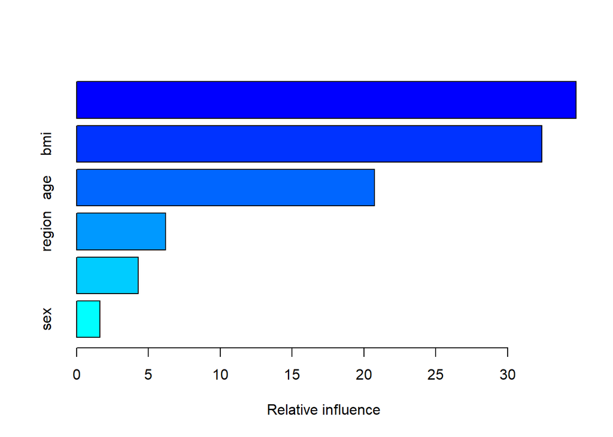

```
##               var   rel.inf
## smoker     smoker 34.773795
## bmi           bmi 32.384724
## age           age 20.747617
## region     region  6.194211
## children children  4.291281
## sex           sex  1.608372
```

```r
summary(charges_boost)
```

Funkcja `plot.gbm()` wykonuje *wykresy częściowej zaleźności*.

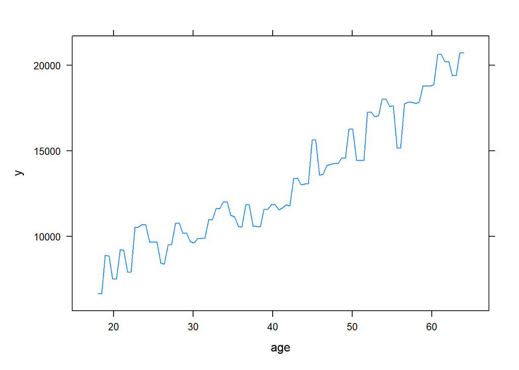

```r
plot(charges_boost, i.var = "age")
```

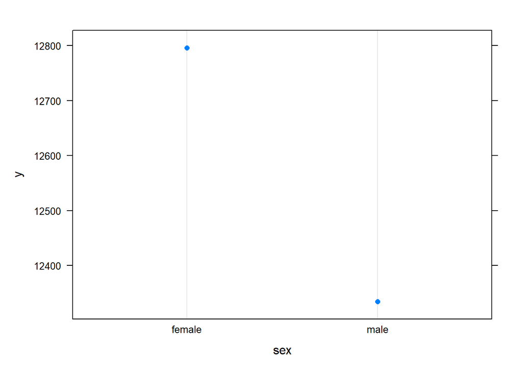

```r
plot(charges_boost, i.var = "sex")
```

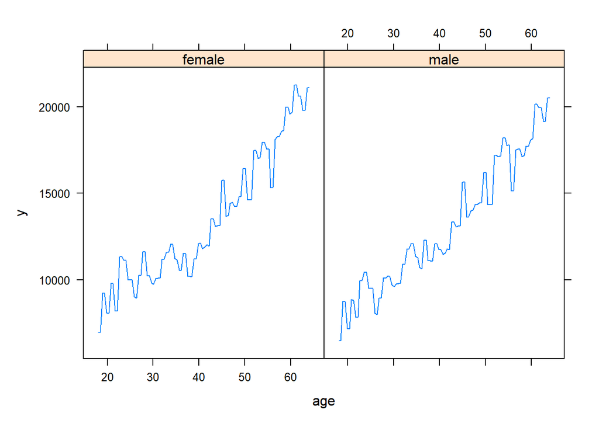

```r
plot(charges_boost, i.var = c("age", "sex"))
```

Oszacowanie błędu testowego dla poprzednio wyznaczonego zbioru walidacyjnego.

```r
set.seed(2)
charges_boost <- gbm(charges ~ ., data = insurance[train,], distribution = "gaussian", interaction.depth = 4, n.trees = 5000)
charges_pred_boost <- predict(charges_boost, newdata = insurance[test,], n.trees = 5000)
mean((charges_pred_boost - insurance$charges[test])^2)
```

```
## [1] 33066393
```

To samo dla $\lambda = 0.01$. Parametr ten odpowiada za spowolnienie uczenia się.

```r
set.seed(2)
charges_boost <- gbm(charges ~ ., data = insurance[train,], distribution = "gaussian", interaction.depth = 4, n.trees = 5000, shrinkage=0.01)
charges_pred_boost <- predict(charges_boost, newdata = insurance[test,], n.trees = 5000)
mean((charges_pred_boost - insurance$charges[test])^2)
```

```
## [1] 26526338
```

# Boosting (klasyfikacja)

```r
insurance$smoker = as.numeric(insurance$smoker)
insurance = transform(insurance, smoker=smoker-1)
smoker_boost <- gbm(smoker ~ ., data = insurance, distribution = "bernoulli", n.trees = 5000, interaction.depth = 4)
smoker_boost
```

```
## gbm(formula = smoker ~ ., distribution = "bernoulli", data = insurance,
##     n.trees = 5000, interaction.depth = 4)
## A gradient boosted model with bernoulli loss function.
## 5000 iterations were performed.
## There were 6 predictors of which 6 had non-zero influence.
```

Funkcja `summary.gbm()` wyznacza ważność predyktorów i (domyślnie) wykonuje odpowiedni wykres.

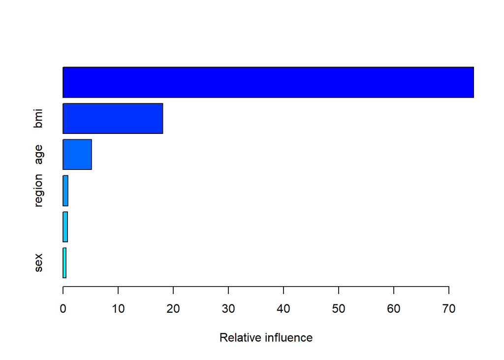

```
##               var    rel.inf
## charges   charges 74.4960310
## bmi           bmi 18.0807412
## age           age  5.1555905
## region     region  0.8899869
## children children  0.8112792
## sex           sex  0.5663712
```

```r
summary(smoker_boost)
```

Najbardziej istotnymi predyktorami jest zmienna charges oraz bmi. Nie istotne są predyktory children oraz sex.

Funkcja `plot.gbm()` wykonuje *wykresy częściowej zaleźności*.

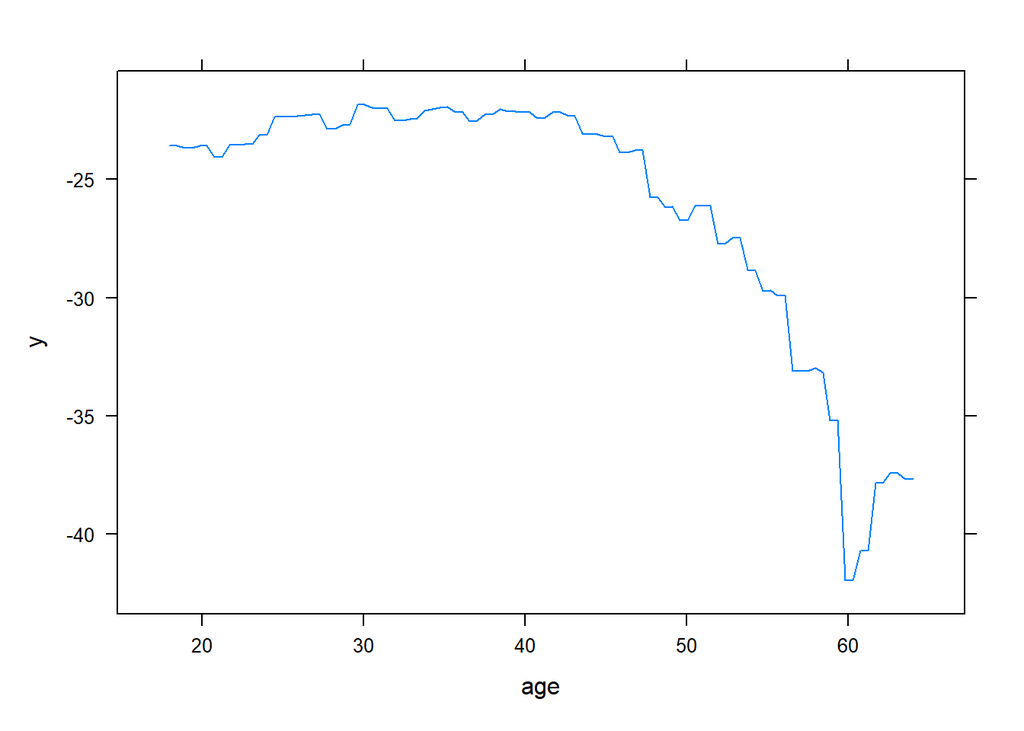

```r
plot(smoker_boost, i.var = "age")
```

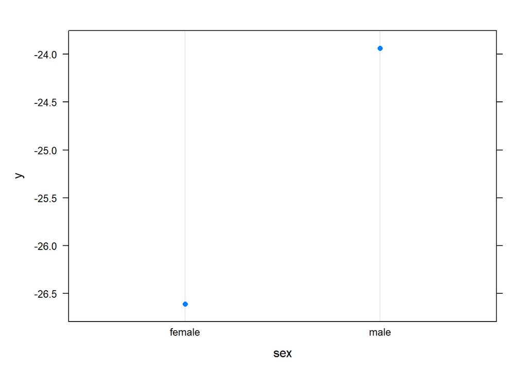

```r
plot(smoker_boost, i.var = "sex")
```

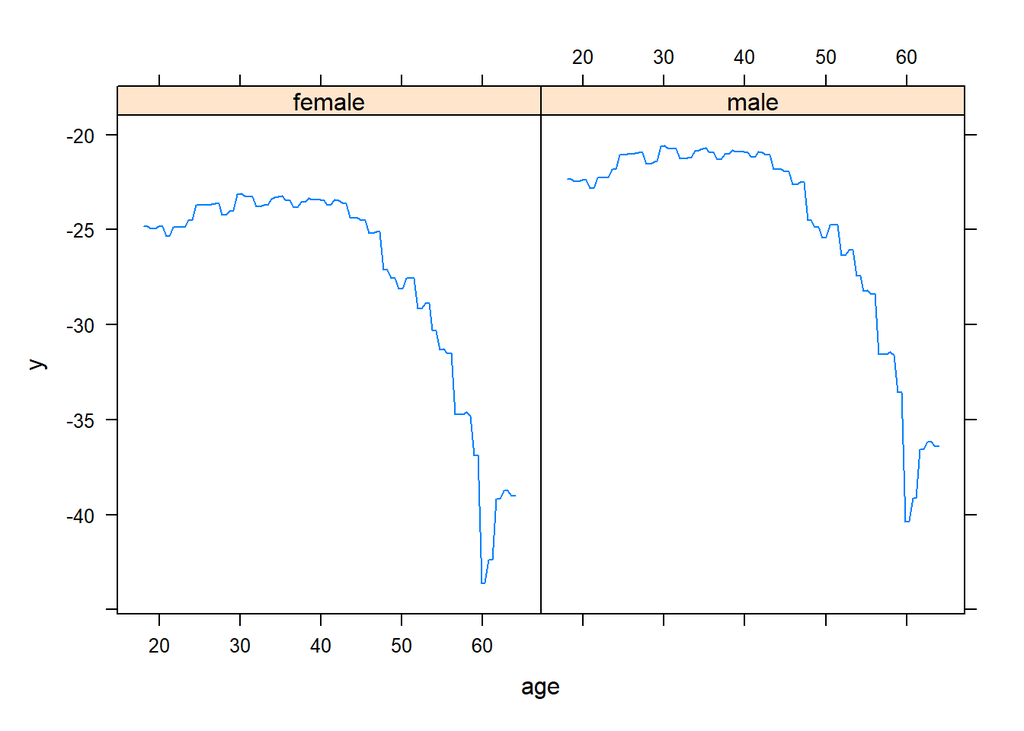

```r
plot(smoker_boost, i.var = c("age", "sex"))
```

Oszacowanie błędu testowego dla poprzednio wyznaczonego zbioru walidacyjnego.

```r
set.seed(2)
smoker_boost <- gbm(smoker ~ ., data = insurance[train,], distribution = "bernoulli", interaction.depth = 4, n.trees = 5000)
smoker_pred_boost <- predict(smoker_boost, newdata = insurance[test,], n.trees = 5000)
mean((smoker_pred_boost - insurance$smoker[test])^2)
```

```
## [1] 16496.31
```

```r
pred_test = predict.gbm(object = smoker_boost,
                   newdata = insurance[test,],
                   n.trees = 500,
                   type = "response")
```

To samo dla $\lambda = 0.01$.

```r
set.seed(2)
smoker_boost <- gbm(smoker ~ ., data = insurance[train,], distribution = "bernoulli", interaction.depth = 4, n.trees = 5000, shrinkage=0.01)
smoker_pred_boost <- predict(smoker_boost, newdata = insurance[test,], n.trees = 5000)
mean((smoker_pred_boost - insurance$smoker[test])^2)
```

```
## [1] 136.1243
```